# VPT with Robots

Error-Rates Analysis: Full model

Joel Currie[^1], Katrina Louise McDonough[^2], Agnieszka Wykowska[^3], Maria Elena Giannaccini[^4], Patric Bach[^5]

2024-12-17

# Full Model:

## Effects of Interest:

### Self Theta:

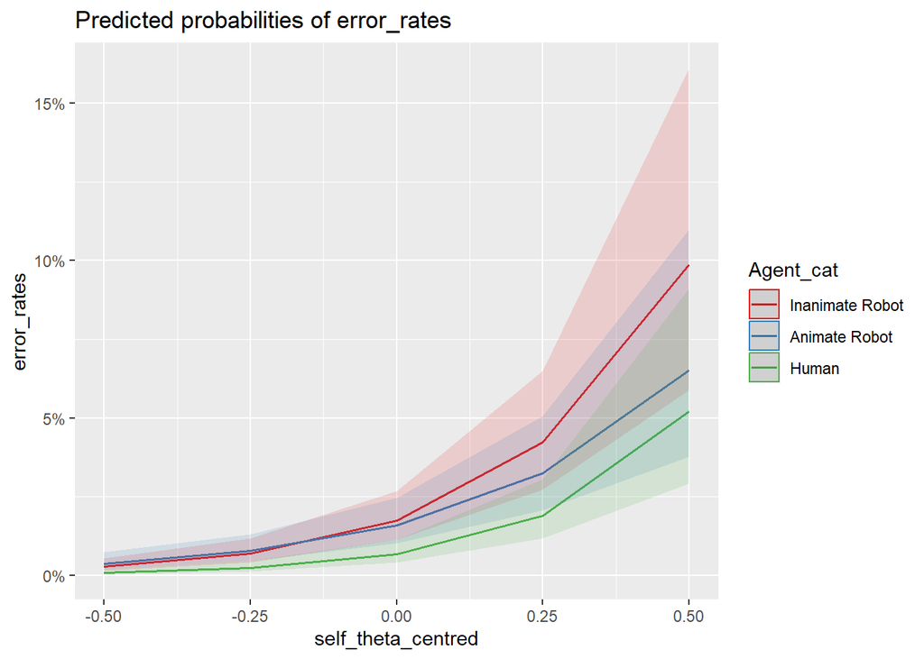

The GLMM model detected a strong $\theta_{self}$ effect ($O.R = 38.2, CI = [15.7 - 93.1], p < .001$), indicating that participants were more likely to make an error correctly identifying characters when they were oriented away from their own perspective, compared to when characters were facing towards them.

### Other Perspective:

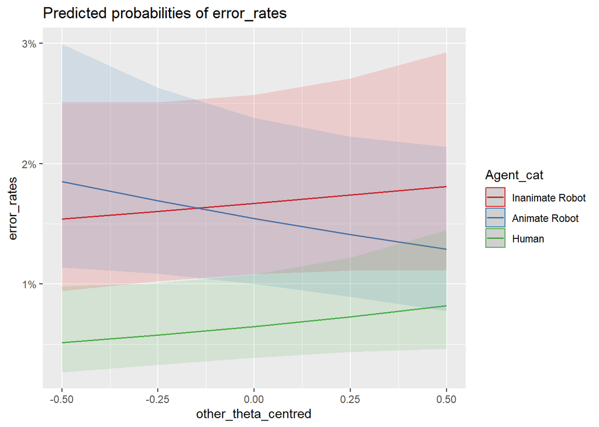

Crucially, our model did not identify a $\theta_{other}$ effect ($O.R = 1.18, CI = [0.76 - 1.83], p = .460$). While error rates numerically showed the same pattern as RTs in our primary analysis, no statistically reliable differences were found indicating no presence of a speed/accuracy trade-off.

## Other Fixed effects and Interactions:

### Exposure:

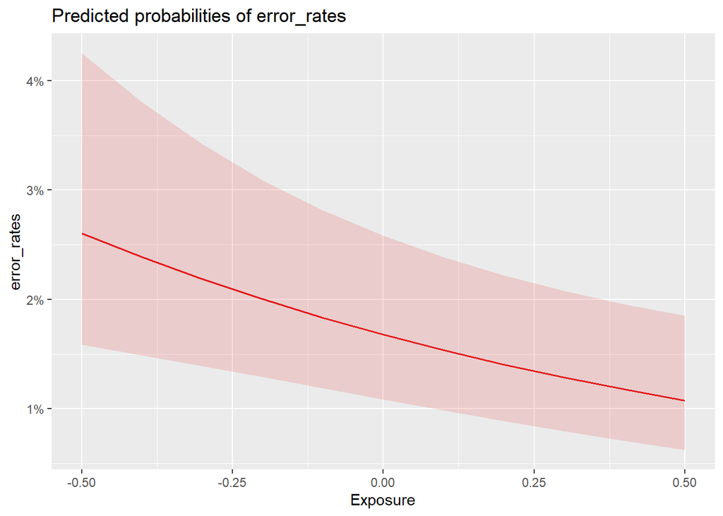

Our model also detected a strong effect of Exposure (Experimental progress), demonstrating that as the experiment progressed participants made less errors: Full-model ($O.R = 0.41, CI = [0.24 - 0.70], p = .001$)

### Agent Category:

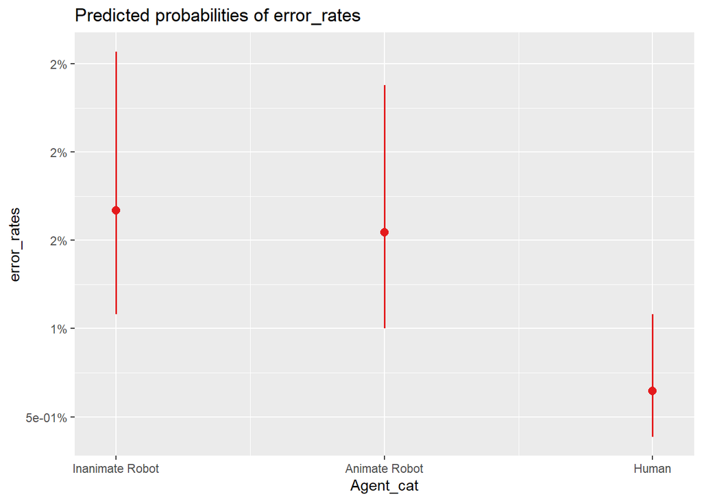

In addition, our full-model revealed a main effect of Agent Category when comparing the Human-Human group with the Human-Inanimate Robot group ($O.R = 0.39, CI = [0.20 - 0.76], p = .005$), and no difference between the Human-Animate Robot and Human-Inanimate Robot groups ($p = .784$),suggesting that participants made less mistakes when paired with another person, compared to being paired with either robot condition.

### Experiment Progress * Agent Category

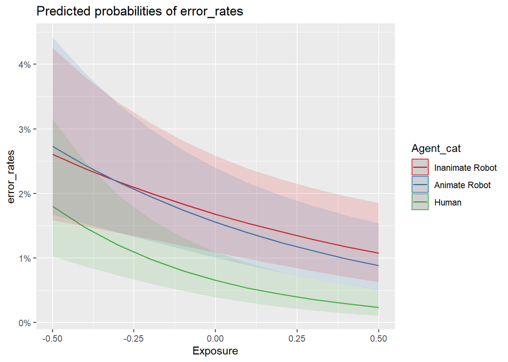

### Experiment Progress * Agent Category * Other Perspective

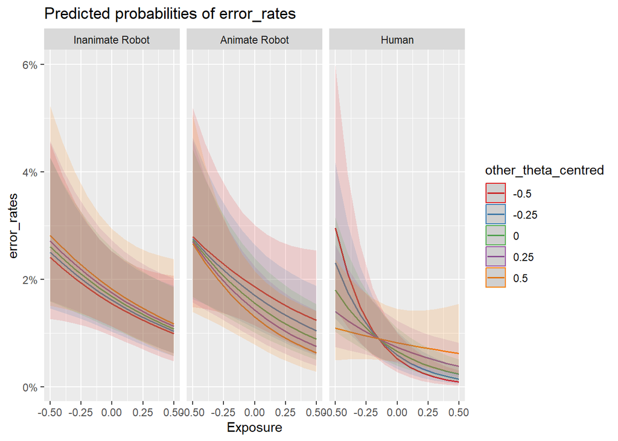

Finally, our model detected a small interaction between Experiment Progress, Agent Category and Other Perspective ($O.R = 19.0, CI = [1.5 - 249.8], p = .025$). This reflects that the Human group started with a strong disadvantage from the the other agents perspective, while this pattern of data inverted as the experiment progressed, while the Animate and Inanimate robot groups stayed static with respect to their initial conditions.

## Model Construciton:

```r
mod_full_corr <- glmer(error_rates ~ self_theta_centred * Exposure * relevel(Agent_cat, ref = "Inanimate Robot") + other_theta_centred * Exposure *  relevel(Agent_cat, ref = "Inanimate Robot")+
                               (1 + self_theta_centred|subject)
                             ,data = filter(data), family = binomial, control = glmerControl(optimizer = "bobyqa"))
```

## Output of model:

|  | error_rates |  |  |
| --- | --- | --- | --- |
| Predictors | Odds Ratios | CI | p |
| (Intercept) | 0.02 | 0.01 – 0.03 | **<0.001** |
| self theta centred | 38.17 | 15.66 – 93.06 | **<0.001** |
| Exposure | 0.41 | 0.24 – 0.70 | **0.001** |
| relevel(Agent cat, ref = “Inanimate Robot”)Animate Robot | 0.92 | 0.50 – 1.70 | 0.784 |
| relevel(Agent cat, ref = “Inanimate Robot”)Human | 0.39 | 0.20 – 0.76 | **0.005** |
| other theta centred | 1.18 | 0.76 – 1.83 | 0.460 |
| self theta centred × Exposure | 0.90 | 0.19 – 4.36 | 0.895 |
| self theta centred × relevel(Agent cat, ref = “Inanimate Robot”)Animate Robot | 0.48 | 0.14 – 1.61 | 0.234 |
| self theta centred × relevel(Agent cat, ref = “Inanimate Robot”)Human | 1.65 | 0.43 – 6.39 | 0.469 |
| Exposure × relevel(Agent cat, ref = “Inanimate Robot”)Animate Robot | 0.78 | 0.36 – 1.70 | 0.539 |
| Exposure × relevel(Agent cat, ref = “Inanimate Robot”)Human | 0.33 | 0.12 – 0.88 | **0.027** |
| Exposure × other theta centred | 1.00 | 0.22 – 4.50 | 0.999 |
| relevel(Agent cat, ref = “Inanimate Robot”)Animate Robot × other theta centred | 0.59 | 0.31 – 1.12 | 0.109 |
| relevel(Agent cat, ref = “Inanimate Robot”)Human × other theta centred | 1.34 | 0.62 – 2.90 | 0.463 |
| self theta centred × Exposure × relevel(Agent cat, ref = “Inanimate Robot”)Animate Robot | 1.53 | 0.16 – 14.52 | 0.712 |
| self theta centred × Exposure × relevel(Agent cat, ref = “Inanimate Robot”)Human | 14.18 | 0.92 – 219.57 | 0.058 |
| (Exposure × relevel(Agent cat, ref = “Inanimate Robot”)Animate Robot) × other theta centred | 0.53 | 0.06 – 4.80 | 0.574 |
| (Exposure × relevel(Agent cat, ref = “Inanimate Robot”)Human) × other theta centred | 19.00 | 1.45 – 249.83 | **0.025** |
| Random Effects |  |  |  |
| σ<sup>2</sup> | 3.29 |  |  |
| τ<sub>00</sub> <sub>subject</sub> | 1.16 |  |  |
| τ<sub>11</sub> <sub>subject.self_theta_centred</sub> | 3.34 |  |  |
| ρ<sub>01</sub> <sub>subject</sub> | 0.04 |  |  |
| ICC | 0.31 |  |  |
| N <sub>subject</sub> | 90 |  |  |
| Observations | 21408 |  |  |
| Marginal R<sup>2</sup> / Conditional R<sup>2</sup> | 0.254 / 0.484 |  |  |

[^1]: University of Aberdeen, j.currie.22@abdn.ac.uk
[^2]: University of East Anglia
[^3]: Istituto Italiano di Tecnologia
[^4]: University of Aberdeen
[^5]: University of Aberdeen